# CS4423 Assignment 2: Part 2

This is a template for your solution to the `networkx` questions on Assignment 2 (Part 2).

### Instructions and Collaboration Policy

This is a homework assignment. You are welcome to collaborate with class-mates if you wish. Please note:

- You may collaborate with at most two other people;
- Each of you must submit your own copy of your work;
- In Cell `[1]`, choose your own node colour in `opts`. It should not be the same as given here (`#ABCDEF`), or the same as your collaborators. For more, see https://matplotlib.org/stable/users/explain/colors/colors.html
- If the question asks you to construct an example, then that example should be unique to you (and your collaborators). If copied from anybody else, all involved will score zero.
- The file(s) you submit must contain a statement on the collaboration: who you collaborated with, and on what part of the assignment.
- *The use of any AI tools, such as ChatGPT or DeepSeek is prohibited, and will be subject to disciplinary procedures.*
- Upload your file, in either **PDF or HTML** formats, to https://universityofgalway.instructure.com/courses/31889/assignments To convert your notebook to `pdf` the easiest method maybe to first export as 'html', then open that in a browser, and then print to pdf.
- Your file must include your name and ID number.

## Preliminaries

### Task 1.1: Give you name, ID, and list of collaborators

**Your name goes here: Ayodeji Ali**

**Your ID number goes here: 20343733**

*Place your collaboration statement here:*

### Task 1.2: Load any Python modules, and choose your own colour for nodes

```python
import networkx as nx
### Change the next line so nodes appear in your favourite colour.
opts = { "with_labels": True, "node_color": "#87CEEB" }
 # show labels; IMPORTANT: Choose your own colour here
```

Other ones that Niall used when preparing solutions. Add any you need:

```python
import numpy as np
import matplotlib.pyplot as plt
import random
import pandas as pd
import math
import statistics
```

## Centrality Measures

Before you do this set of tasks, it may be helpful to review the example at the end of [Week 7 Part 2](https://www.niallmadden.ie/2425-CS4423/W07/CS4423-W07-Part-2.html)

**Adjacency Lists**.  
One way of representing a graph is an as **adjacency list**. It has one row per node. That row starts with the node label, followed by a colon, followed by a list of its neighbours. For an undirected graph, one does not list an edge twice.

Consider the following list, for a graph, $G_1$, on the nodes $\{1, 2, 3, \dots, 10\}$:

```
1: 2 3 4 6 7
2: 3
3: 4
4: 5 8
5: 6
6: 7
7:
8: 9 10
9:
10:
```

### TASK 2.1: Define $G_1$ in `networkx` and draw it.

Let $G_1$ be the network prescribed by the adjacency list above. Define it as a `networkx` network, and draw it.

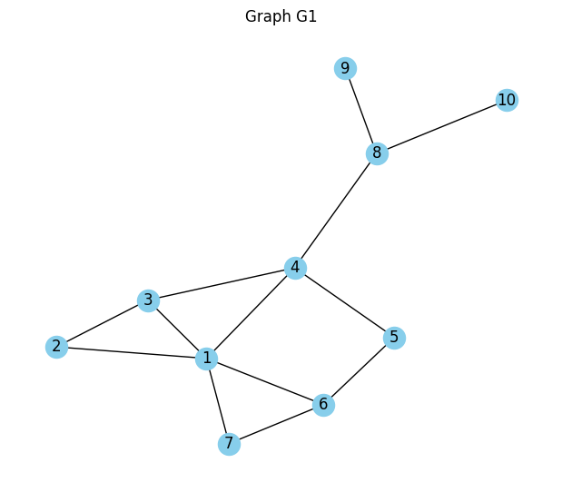

```python
### YOUR CODE for defining G1 GOES HERE:
# Define Graph G1 using the given adjacency list
G1 = nx.Graph()
edges_G1 = [(1,2), (1,3), (1,4), (1,6), (1,7),
            (2,3),
            (3,4),
            (4,5), (4,8),
            (5,6),
            (6,7),
            (8,9), (8,10)]
G1.add_edges_from(edges_G1)

# Draw G1 using the specified options
plt.figure(figsize=(6,5))
nx.draw(G1, **opts)
plt.title("Graph G1")
plt.show()
```

### TASK 2.2: Compute Centralities

Compute the Degree, Eigenvector, Closeness, and Betweenness Centralities of the nodes in this graph. Display all four in a table (using a pandas `DataFrame`) sorted by the eigenvector centrality.

```python
### Give your answer for computing the centralities in this cell.
# Compute centralities for G1
deg_centrality = nx.degree_centrality(G1)
eig_centrality = nx.eigenvector_centrality(G1)
clo_centrality = nx.closeness_centrality(G1)
bet_centrality = nx.betweenness_centrality(G1)
```

```python
### Give your code for displating the centralities in a table here:
# Create a DataFrame with the centralities and sort by eigenvector centrality
df_centralities = pd.DataFrame({
    "Degree": deg_centrality,
    "Eigenvector": eig_centrality,
    "Closeness": clo_centrality,
    "Betweenness": bet_centrality
}).sort_values(by="Eigenvector", ascending=False)

df_centralities
```

|  | Degree | Eigenvector | Closeness | Betweenness |
| --- | --- | --- | --- | --- |
| 1 | 0.555556 | 0.544133 | 0.600000 | 0.351852 |
| 4 | 0.444444 | 0.424131 | 0.642857 | 0.560185 |
| 3 | 0.333333 | 0.398195 | 0.529412 | 0.064815 |
| 6 | 0.333333 | 0.333310 | 0.450000 | 0.050926 |
| 2 | 0.222222 | 0.296646 | 0.409091 | 0.000000 |
| 7 | 0.222222 | 0.276219 | 0.428571 | 0.000000 |
| 5 | 0.222222 | 0.238443 | 0.473684 | 0.055556 |
| 8 | 0.333333 | 0.166524 | 0.500000 | 0.416667 |
| 9 | 0.111111 | 0.052423 | 0.346154 | 0.000000 |
| 10 | 0.111111 | 0.052423 | 0.346154 | 0.000000 |

### TASK 2.3: Draw the graph with node size proportional to eigenvector centrality

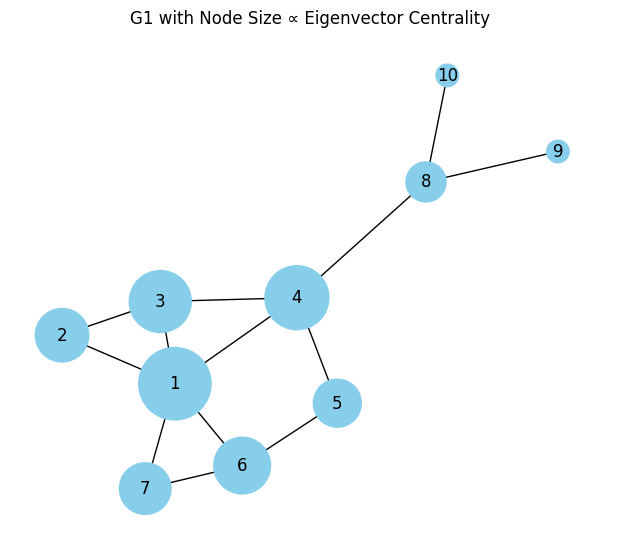

```python
### Give your answer in this cell. Add more cells if needed.
# Determine node sizes based on eigenvector centrality
sizes = [5000 * eig_centrality[n] for n in G1.nodes()]

plt.figure(figsize=(6,5))
nx.draw(G1, node_size=sizes, **opts)
plt.title("G1 with Node Size ∝ Eigenvector Centrality")
plt.show()
```

### TASK 2.4: Make your own example

If TASK 2.3 went as intended, you should find that, for $G_1$, Node **4** had both the greatest closeness and betweenness centrality. Make up an example of a graph, $G_2$, which the node with the greatest closeness centrality is different from the one with the greatest betweenness centrality. Define and draw the graph in `networkx`, and compute the centralities to verify your result.

*WARNING* You have to construct this example yourself. Do not try to use the same graph as anyone other than a listed collaborator.

```python
### Give your answer in this cell. Make sure your network is called G2
# Define a custom graph G2
G2 = nx.Graph()
edges_G2 = [(1,2), (2,3), (3,4), (4,5), (3,6), (6,7), (7,8), (8,9), (6,10)]
G2.add_edges_from(edges_G2)
```

Don't remove the following cell. It will plot your network, `G2`, and identify the nodes with greatest betweenness and closeness centralities.

```
Node 3 has the greatest betweenness, and Node 3 has the max closeness
```

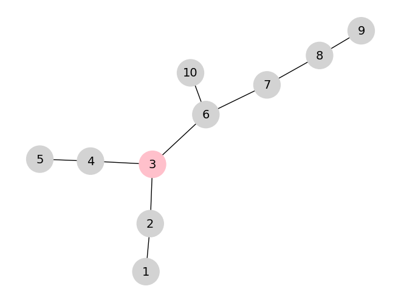

```python
### Do not delete this cell. It has an overly-elaborate way of showing the difference in centralities.
CC = nx.closeness_centrality(G2)
BC = nx.betweenness_centrality(G2)

max_betweenness = max(BC, key=BC.get)
max_closeness = max(CC, key=CC.get)
print(f"Node {max_betweenness} has the greatest betweenness, and Node {max_closeness} has the max closeness")
# Node colors: highlight key nodes
node_colors = []
for node in G2.nodes():
    if node == max_betweenness:
        node_colors.append("pink")  # Highest betweenness
    elif node == max_closeness:
        node_colors.append("skyblue")  # Highest closeness
    else:
        node_colors.append("lightgray")

nx.draw(G2, with_labels=True, node_color=node_colors, edge_color="black", node_size=1000, font_size=14)
```

## Random Networks

We'll learn in class that one way in which ER models don't reflect some real-world networks in that they tend to have fewer triangles (3-cycles) than real-world graphs. Here a *triangle* in $G$ means a subgraph that is isomorphic to $C_3$. So, for example, $C_3$ has 1 triangle, and the [Wheel Graph, $W_n$](https://en.wikipedia.org/wiki/Wheel_graph) has $n-1$.

Asides:

- It is not a homework question, but work out why you should divide the trace of $B$ by 6.
- Well done: you've just come up with a proof that the trace of the cube of any $0-1$ matrix is divisible by 6.

### TASK 3.1: Count Triangles

Write a function (**with some sensible name of your own choosing**) that takes as its input a graph, and returns the total number of triangles in $G$. Tip: `np.trace()` returns the trace of a 2D numpy array.

```python
### Give your code for defining your function in this cell:
def count_triangles(G):
    A = nx.adjacency_matrix(G).todense()
    B = np.linalg.matrix_power(A, 3)
    # Each triangle is counted 6 times in the trace of B
    return int(np.trace(B) / 6)
```

Verify that your function works by checking that, e.g., the graph returned by `nx.wheel_graph(5)` has 4 triangles.

```python
### Give your code that verifies your function works for a $W_5$.
# Test the function with a Wheel Graph W5 (expected triangles: 4)
W5 = nx.wheel_graph(5)
print("Triangles in W5:", count_triangles(W5))  # Expected output: 4
```

[output not shown]

### TASK 3.2: Comparing $G_{ER}(n,m)$ with graphs from social science

`networkx` comes with some generators from graphs that are much-studied in the network science. In [Week7: Part 2](https://www.niallmadden.ie/2425-CS4423/W07/CS4423-W07-Part-2.html#Example:-15th-century-Florentine-marriages) we considered the *Florentine Families* graph, which is generate by `nx.florentine_families_graph()`. There are others such as

- The [Karate Club Graph](https://en.wikipedia.org/wiki/Zachary%27s_karate_club) which is generated using `nx.karate_club_graph()`
- The (Les Miserables network)[https://networkx.org/documentation/stable/reference/generated/networkx.generators.social.les_miserables_graph.html] generated by `nx.les_miserables_graph()`

```python
def count_triangles(G):
    # Get the adjacency matrix as a dense matrix
    A = nx.adjacency_matrix(G).todense()
    # Raise A to the power of 3
    B = np.linalg.matrix_power(A, 3)
    # The trace of B counts each triangle 6 times
    return int(np.trace(B) / 6)
```

For each of the three networks mentioned above:

- Generate the graph, and output the number of order and size of the network, and the number of triangles it has.
- Use `nx.gnm_random_graph()` to make a graph drawn from $G_{ER}(n,m)$ that has the same size and order. Output how many triangles it has.

```python
### Your answer for the Florentine Families graph goes here.

# Generate the Florentine Families graph
G_florentine = nx.florentine_families_graph()

# Count nodes, edges, and triangles in the real graph
n_florentine = G_florentine.number_of_nodes()
m_florentine = G_florentine.number_of_edges()
tri_real_florentine = count_triangles(G_florentine)

# Generate an ER graph with the same number of nodes and edges
G_er_florentine = nx.gnm_random_graph(n_florentine, m_florentine, seed=42)
tri_er_florentine = count_triangles(G_er_florentine)

# Create and display a DataFrame for comparison
import pandas as pd

df_florentine = pd.DataFrame({
    "Graph": ["Florentine Families"],
    "Nodes": [n_florentine],
    "Edges": [m_florentine],
    "Triangles (Real)": [tri_real_florentine],
    "Triangles (ER)": [tri_er_florentine]
})

df_florentine
```

|  | Graph | Nodes | Edges | Triangles (Real) | Triangles (ER) |
| --- | --- | --- | --- | --- | --- |
| 0 | Florentine Families | 15 | 20 | 3 | 4 |

```python
### Your answer for the Karate Club network goes here.

# Generate the Karate Club graph
G_karate = nx.karate_club_graph()

# Count nodes, edges, and triangles in the real graph
n_karate = G_karate.number_of_nodes()
m_karate = G_karate.number_of_edges()
tri_real_karate = count_triangles(G_karate)

# Generate an ER graph with the same number of nodes and edges
G_er_karate = nx.gnm_random_graph(n_karate, m_karate, seed=42)
tri_er_karate = count_triangles(G_er_karate)

# Create and display a DataFrame for comparison
df_karate = pd.DataFrame({
    "Graph": ["Karate Club"],
    "Nodes": [n_karate],
    "Edges": [m_karate],
    "Triangles (Real)": [tri_real_karate],
    "Triangles (ER)": [tri_er_karate]
})

df_karate
```

|  | Graph | Nodes | Edges | Triangles (Real) | Triangles (ER) |
| --- | --- | --- | --- | --- | --- |
| 0 | Karate Club | 34 | 78 | 1821 | 15 |

```python
### Your answer for the Les Mis network goes here.
# Generate the Les Miserables graph
G_les = nx.les_miserables_graph()

# Count nodes, edges, and triangles in the real graph
n_les = G_les.number_of_nodes()
m_les = G_les.number_of_edges()
tri_real_les = count_triangles(G_les)

# Generate an ER graph with the same number of nodes and edges
G_er_les = nx.gnm_random_graph(n_les, m_les, seed=42)
tri_er_les = count_triangles(G_er_les)

# Create and display a DataFrame for comparison
df_les = pd.DataFrame({
    "Graph": ["Les Miserables"],
    "Nodes": [n_les],
    "Edges": [m_les],
    "Triangles (Real)": [tri_real_les],
    "Triangles (ER)": [tri_er_les]
})

df_les
```

|  | Graph | Nodes | Edges | Triangles (Real) | Triangles (ER) |
| --- | --- | --- | --- | --- | --- |
| 0 | Les Miserables | 77 | 254 | 55513 | 51 |

## Extras

The following isn't part of the assignment, but you might find it interesting:

1. Use `np.linspace(0,1,100)` to create an array of probabilities.
2. For $n=100$ make a $G_{ER}(n,p)$ graph with the values of $p$ drawn from above, and count the number of triangles. Call this $T(G)$.
3. I conjecture that $T(G)/m(G) \approx C p^2$, for some constant $C$ that depends on $n$. Try to produce a plot that supports (or refutes) this conjecture, and try to estimate $C$